# *Machine Learning - Course Project*

## **Background**

Using devices such as Jawbone Up, Nike FuelBand, and Fitbit it is now possible to collect a large amount of data about personal activity relatively inexpensively. These type of devices are part of the quantified self movement - a group of enthusiasts who take measurements about themselves regularly to improve their health, to find patterns in their behavior, or because they are tech geeks. One thing that people regularly do is quantify how much of a particular activity they do, but they rarely quantify how well they do it. In this project, your goal will be to use data from accelerometers on the belt, forearm, arm, and dumbell of 6 participants. They were asked to perform barbell lifts correctly and incorrectly in 5 different ways. More information is available from the website here: http://groupware.les.inf.puc-rio.br/har (see the section on the Weight Lifting Exercise Dataset).

## **Data**

The training data for this project are available here:

https://d396qusza40orc.cloudfront.net/predmachlearn/pml-training.csv

The test data are available here:

https://d396qusza40orc.cloudfront.net/predmachlearn/pml-testing.csv

The data for this project come from this source: http://groupware.les.inf.puc-rio.br/har.

## **Working directory and packages**

```r
getwd()
```

```
## [1] "C:/Users/usuario/Documents/CN/Coursera/DataScienceSpecialization/MachineLearning/CourseProject"
```

```r
suppressMessages(library(caret))
#I set seed for reproducibility
set.seed(2468)
```

### **Loading data**

```r
trainingURL<-"https://d396qusza40orc.cloudfront.net/predmachlearn/pml-training.csv"
testingURL<-"https://d396qusza40orc.cloudfront.net/predmachlearn/pml-testing.csv"

training <- read.csv(url(trainingURL), na.strings=c("NA","#DIV/0!",""))
testing<-read.csv(url(testingURL), na.strings=c("NA","#DIV/0!",""))
```

### **Data Cleaning**

By executing the following code many things can be learned (code results have been hidden in output HTML document for readability)

```r
str(training)
colnames(training)
sapply(training,class)
```

1. “str” tells us there are 19622 obs. of 160 variables, and many of them seem to have lots of NA´s values.
2. Since there is no Code Book available, “colnames” provides a feeling of which variables may not be useful for our analysis (assuming that labels are descriptive). The first seven (7) columns meet that criterium.
3. The last command lets us know variable types, (“classe” is a factor-type one, with five levels, A,B,C,D & E).

Let´s clean our training dataset based on these results:

```r
# Removal of NA´s. Columns with an excess of 90%  NA´s are removed (the 90% threshold is an arbitrary choice of mine)
training<-training[,!(colSums(is.na(training))>=0.9*nrow(training))]
# Removal of "useless" columns
training<-training[,-c(1:7)]
dim(training)
```

```
## [1] 19622    53
```

The result shows we have kept all our information (there are still 19622 observations), but now they are concentrated in just 53 columns (instead of the original 160).

### **Data Partitioning**

```r
##Creating subsets of training and testing data from the original training dataset
inTrain<-createDataPartition(training$classe,p=0.6,list=FALSE)
trainingData<-training[inTrain,]
testingData<-training[-inTrain,]
dim(trainingData);dim(testingData)
```

```
## [1] 11776    53
```

```
## [1] 7846   53
```

### **Model training**

I will use the randomForest function (from the randomForest package) to get a model using the subset of training data created just above. I made this choice because (from the lectures): “Random forests are usually one of the two top performing algorithms …in prediction contests” and “(are) often very accurate”

Regarding cross validation, “In random forests, there is no need for cross-validation or a separate test set to get an unbiased estimate of the test set error. It is estimated internally, during the run” (see: “The out-of-bag (oob) error estimate” at http://www.stat.berkeley.edu/~breiman/RandomForests/cc_home.htm#ooberr)

```r
suppressMessages(library(randomForest))
rfModelFit<-randomForest(classe~.,data=trainingData)
rfModelFit
```

```
##
## Call:
##  randomForest(formula = classe ~ ., data = trainingData)
##                Type of random forest: classification
##                      Number of trees: 500
## No. of variables tried at each split: 7
##
##         OOB estimate of  error rate: 0.59%
## Confusion matrix:
##      A    B    C    D    E  class.error
## A 3346    2    0    0    0 0.0005973716
## B   12 2262    5    0    0 0.0074594120
## C    0    9 2041    4    0 0.0063291139
## D    0    0   27 1901    2 0.0150259067
## E    0    0    1    8 2156 0.0041570439
```

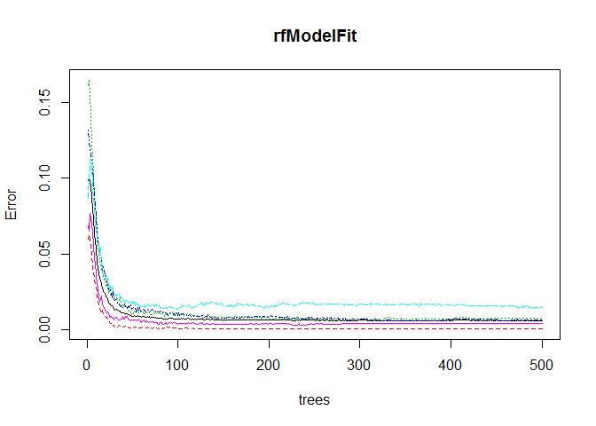

```r
plot(rfModelFit)
```

Results are good: a) a low out-of-bag (OOB, or out-of sample) error estimate of 0.59% (see https://stat.ethz.ch/education/semesters/ss2012/ams/slides/v10.2.pdf , slide 7, or the previous reference from Berkeley), and b) confussion matrix shows good fit on the training set.

### **Prediction on the testing subset using the model**

Let´s use the model on the testingData subset

```r
#Perform prediction
predictionTestingData<-predict(rfModelFit, newdata=testingData)
#Show results
confusionMatrix(predictionTestingData,testingData$classe)
```

```
## Confusion Matrix and Statistics
##
##           Reference
## Prediction    A    B    C    D    E
##          A 2230    4    0    0    0
##          B    2 1509    9    0    0
##          C    0    5 1359   12    0
##          D    0    0    0 1271    1
##          E    0    0    0    3 1441
##
## Overall Statistics
##
##                Accuracy : 0.9954
##                  95% CI : (0.9937, 0.9968)
##     No Information Rate : 0.2845
##     P-Value [Acc > NIR] : < 2.2e-16
##
##                   Kappa : 0.9942
##  Mcnemar's Test P-Value : NA
##
## Statistics by Class:
##
##                      Class: A Class: B Class: C Class: D Class: E
## Sensitivity            0.9991   0.9941   0.9934   0.9883   0.9993
## Specificity            0.9993   0.9983   0.9974   0.9998   0.9995
## Pos Pred Value         0.9982   0.9928   0.9876   0.9992   0.9979
## Neg Pred Value         0.9996   0.9986   0.9986   0.9977   0.9998
## Prevalence             0.2845   0.1935   0.1744   0.1639   0.1838
## Detection Rate         0.2842   0.1923   0.1732   0.1620   0.1837
## Detection Prevalence   0.2847   0.1937   0.1754   0.1621   0.1840
## Balanced Accuracy      0.9992   0.9962   0.9954   0.9941   0.9994
```

We get good prediction results, as indicated by the confussion matrix.

### **Prediction on the testing set for submission**

Let´s apply the model to predict on the original testing set

```r
prediction<-predict(rfModelFit, newdata=testing, type="Class")
prediction
```

```
##  1  2  3  4  5  6  7  8  9 10 11 12 13 14 15 16 17 18 19 20
##  B  A  B  A  A  E  D  B  A  A  B  C  B  A  E  E  A  B  B  B
## Levels: A B C D E
```